# Part 3: Iris Flower Data Analysis

## Data analysis to be conducted in R.

*The data set used is built-in the studio R package. It is called the “Edgar Anderson’s Iris Data” set. The data is in ‘data frame’ format and named ‘iris’. Type ‘iris’ in R Help to find out more about the data set.*

### 1) Quote the description of the data set as found default R Help. Present the data briefly by indicating the variables names, their statistical class, the size of the vectors (1D arrays), and by showing first 6 lines of values for each variables.

**This famous (Fisher’s or Anderson’s) iris data set gives the measurements in centimeters of the variables sepal length and width and petal length and width, respectively, for 50 flowers from each of 3 species of iris. The species are Iris setosa, versicolor, and virginica.**

```r
str(iris)
```

```
'data.frame':   150 obs. of  5 variables:
 $ Sepal.Length: num  5.1 4.9 4.7 4.6 5 5.4 4.6 5 4.4 4.9 ...
 $ Sepal.Width : num  3.5 3 3.2 3.1 3.6 3.9 3.4 3.4 2.9 3.1 ...
 $ Petal.Length: num  1.4 1.4 1.3 1.5 1.4 1.7 1.4 1.5 1.4 1.5 ...
 $ Petal.Width : num  0.2 0.2 0.2 0.2 0.2 0.4 0.3 0.2 0.2 0.1 ...
 $ Species     : Factor w/ 3 levels "setosa","versicolor",..: 1 1 1 1 1 1 1 1 1 1 ...
```

**The data is composed of 5 different variables. These variables are:**

- Sepal.Lenght which contains continuous numeric values
- Sepal.Width which contains continuous numeric values
- Petal.Length which contains continuous numeric values
- Petal.Width which contains continuous numeric values
- Species which contains categorical values

```r
total_records <- nrow(iris)
```

**There are a total of 150 records. We can see the first six:**

```r
head(iris, 6)
```

|  | Sepal.Length | Sepal.Width | Petal.Length | Petal.Width | Species |
| --- | --- | --- | --- | --- | --- |
| 1 | 5.1 | 3.5 | 1.4 | 0.2 | setosa |
| 2 | 4.9 | 3.0 | 1.4 | 0.2 | setosa |
| 3 | 4.7 | 3.2 | 1.3 | 0.2 | setosa |
| 4 | 4.6 | 3.1 | 1.5 | 0.2 | setosa |
| 5 | 5.0 | 3.6 | 1.4 | 0.2 | setosa |
| 6 | 5.4 | 3.9 | 1.7 | 0.4 | setosa |

### 2) Calculate and present the standard descriptive statistics (central and dispersion) for all 4 numerical variables.

```r
num.vars <- iris[,1:4]
summary(num.vars)
```

```
  Sepal.Length    Sepal.Width     Petal.Length    Petal.Width
 Min.   :4.300   Min.   :2.000   Min.   :1.000   Min.   :0.100
 1st Qu.:5.100   1st Qu.:2.800   1st Qu.:1.600   1st Qu.:0.300
 Median :5.800   Median :3.000   Median :4.350   Median :1.300
 Mean   :5.843   Mean   :3.057   Mean   :3.758   Mean   :1.199
 3rd Qu.:6.400   3rd Qu.:3.300   3rd Qu.:5.100   3rd Qu.:1.800
 Max.   :7.900   Max.   :4.400   Max.   :6.900   Max.   :2.500
```

- **Sepal length** spans from a minimum of 4.3cm to 7.9cm. The mean value is 5.843cm while the median is 5.8cm. The mean and median values are very close to each other, this could imply that the data is symmetrical.

[output not shown]

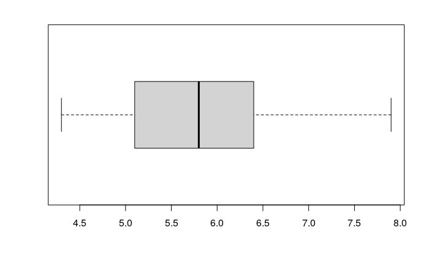

```r
boxplot(iris$Sepal.Length, horizontal=TRUE)
```

In the boxplot, we notice that the data is right skewed. We can calculate the standard deviation to see the dispersion of the feature.

```r
sd_s_l <- sd(iris$Sepal.Length)
```

**The standard deviation of Sepal Length is $\sigma=0.8280661$**.

Sepal length seems to exhibit a low variation.  
- **Sepal width** as well as sepal length, has a median value which is very close to the mean. The 1st and 3rd quartiles seem to be equidistant.

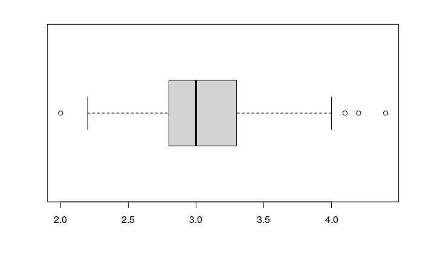

```r
boxplot(iris$Sepal.Width, horizontal=TRUE)
```

Sepal width appears to be normally distributed and also shows few outliers.

```r
sd_s_w <- sd(iris$Sepal.Width)
```

**The standard deviation of Sepal Width is $\sigma=0.4358663$**.

- **Petal length** seems to be less symmetrical as the mean and median values differ: the median is significantly higher than the mean. Altough, we can also notice that the 1st quartile has a small value compared to the other quartiles meaning that there are many data points included in the small range.

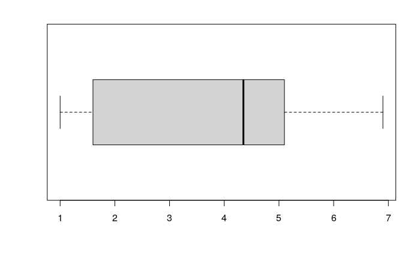

```r
boxplot(iris$Petal.Length, horizontal=TRUE)
```

```r
sd_p_l <- sd(iris$Petal.Length)
```

**The standard deviation of Petal Length is $\sigma=1.7652982$**.

It also has a higher dispersion than the two features previously examined.  
- **Petal width** has similar central statistics to petal length, and as well shows many data points in the small range of values.

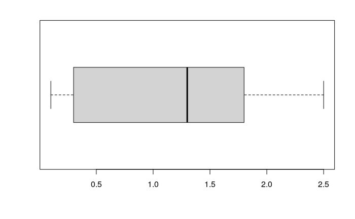

```r
boxplot(iris$Petal.Width, horizontal=TRUE)
```

In fact the distribution looks similar to the one of petal length.

```r
sd_p_w <- sd(iris$Petal.Width)
```

**The standard deviation of Petal Width is $\sigma=0.7622377$**.

In this case the standard deviation has a smaller value but it is to be expected taken the scale into consideration.

### 3) Consider all possible scatter plots of the 4 numerical variables against one another.

#### i) How many plots are possible in theory? How many scatter plots are there, if one uses each variable pair once? Use factorial based formulas.

We have a total of four variables and we need to pick two at the time. There is no repetition as it is not necessary to plot one variable against itself.

$$^{4}C_{2}=\frac{n!}{k!(n-k)!}$$

```r
  n <- 4
  k <- 2
  max_plots <- factorial(n)/(factorial(k)*factorial(n-k))
```

**6 is the total number of combinations for choosing 2 elements at a time from 4 distinct elements.**

#### ii) Plot all scatter plots using each variable pair once.

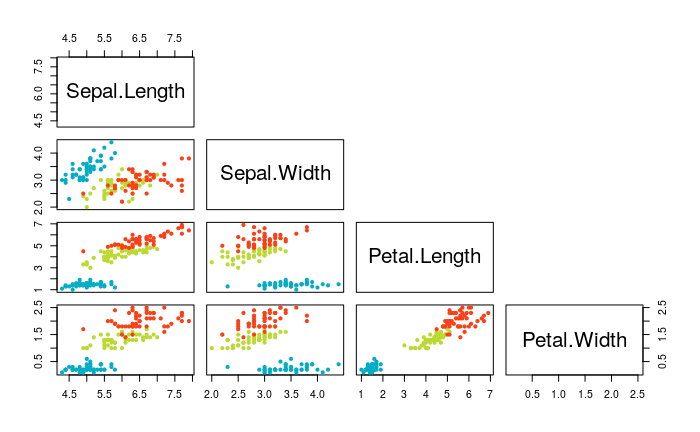

```r
pairs(num.vars,
      pch = 20,
      col = c("#04ADC5", "#BBD931", "#FB3F16")[iris$Species] ,
      upper.panel=NULL)
```

#### iii) Indicate, which plots seem to exhibit a linear relationship (straight line)? Conclude in one sentence what these relationships indicate.

1. Petal length vs. Petal width
2. Sepal length vs. Petal length
3. Sepal lenght vs. Petal width

The positive linear relationship of the above variables implies that they increase by approximately the same rate as the other variables changes by one unit.

### 4)

#### i) Create (relative) frequency histograms for each variable.

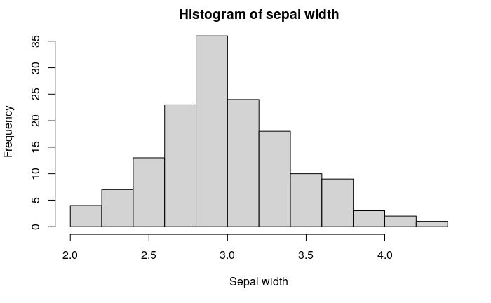

```r
hist(iris$Sepal.Width, freq=TRUE, main='Histogram of sepal width', xlab='Sepal width')
```

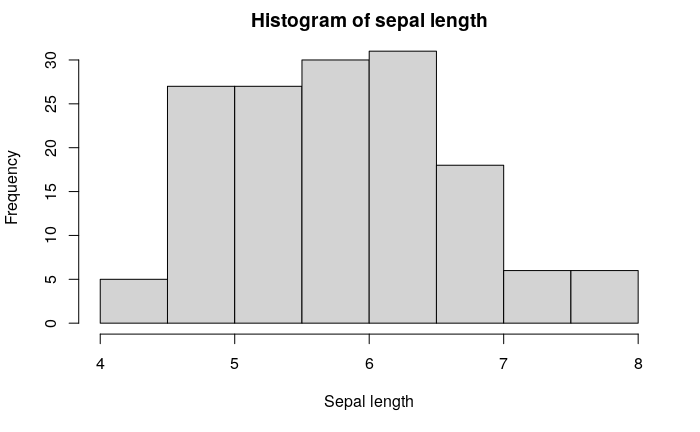

```r
hist(iris$Sepal.Length, freq=TRUE, main='Histogram of sepal length', xlab='Sepal length')
```

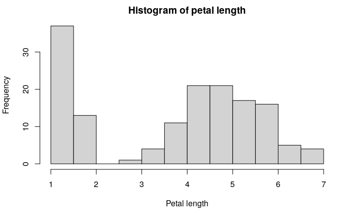

```r
hist(iris$Petal.Length, freq=TRUE, main='Histogram of petal length', xlab='Petal length')
```

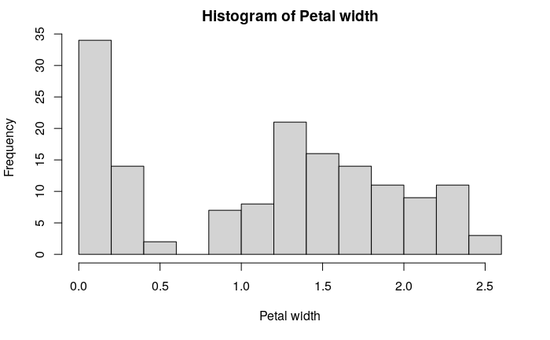

```r
hist(iris$Petal.Width, freq=TRUE, main='Histogram of Petal width', xlab='Petal width')
```

#### ii) Which variable appears to be normally distributed? Below this will be variable X.

Sepal width appears to be normally distributed as both the histogram and boxplot resemble the shape of a normal distribution. We can also verify this visually with a quantile-quantile plot.

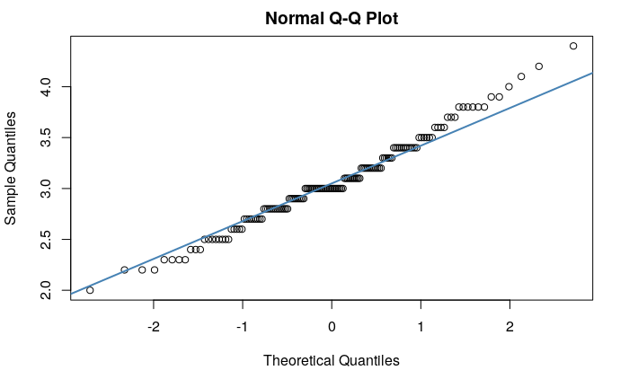

```r
qqnorm(iris$Sepal.Width, pch=1)
qqline(iris$Sepal.Width, col="steelblue", lwd=2)
```

#### iii) Isolate the variable which appears normally distributed, X. Based on its mean and its standard deviation, define (in a formula) the model normal probability density function and plot it.

```r
X <- iris$Sepal.Width

X.mean <- mean(X)
```

**The mean is $\hat{x}=3.0573333$**

```r
X.sd <- sd(X)
```

**The standard deviation is $s=0.4358663$**

According to the central limit theorem, with a large enough sample we can use the sample mean and the sample standard deviation instead of the population values. Hence, we can define a formula to model the normal probability density function given that $\mu\approx\hat{x}=3.06$ and $\sigma\approx\text{s}=0.44$.

$$f(x)=\frac{1}{\sigma\sqrt{2\pi}}e^{-\frac{(x-\mu)^{2}}{2\sigma^{2}}}$$

We can use the `dnorm` function to display the obtained normal distribution.

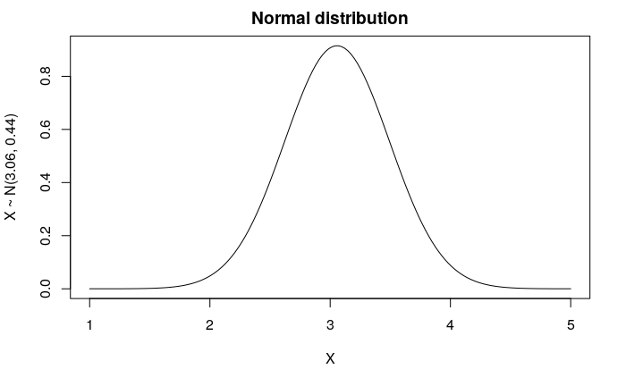

```r
x.axis <- seq(1, 5, length=150)
y.axis <- dnorm(x.axis, mean=X.mean, sd=X.sd)
plot(x.axis, y.axis, type='l', main="Normal distribution",
  xlab="X", ylab="X ~ N(3.06, 0.44)")
```

### 5) Consider the data in X as a population and assume it is normally distributed. Estimate the probability that iris flowers have:

*A helper function to represent data as percentage:*

```r
percent <- function(number){
  return(sprintf("%1.2f%%", number * 100))
}
```

Assuming that X is normally distributed, we can calculate the expected probabilities using the mean and standard deviation obtained previously.

#### i) X > 3

```r
pn_i <- pnorm(3, mean=X.mean, sd=X.sd, lower.tail=FALSE)
```

The expected probability of sepal width being higher than 3cm assuming that it is normally distributed is **0.5523255** -> **55.23%**.

```r
p_i <- sum(X > 3)/length(X)
```

In our sample, the observed probability of iris flowers that have a sepal width higher than 3 is **0.4466667** -> **44.67%**.

#### ii) 2.5 < X < 3.5

Analogously, we can calculate the expected probabilities of sepal width being included in the interval between 2.5cm and 3.5cm.

```r
pn_ii <- (pnorm(3.5, mean=X.mean, sd=X.sd, lower.tail=TRUE) -
          pnorm(2.5,mean=X.mean, sd=X.sd, lower.tail=TRUE))
```

The expected probability is **0.7445856** -> **74.46%**.

```r
p_ii <- sum(2.5 < X & X < 3.5)/length(X)
```

The observed probability in our sample is **0.7066667** -> **70.67%**.

#### iii) X < 2.5

Finally, the expected probabilities of sepal width being less than 2.5cm can be, again, calculated using the `pnorm` function.

```r
pn_iii <- pnorm(2.5, mean=X.mean, sd=X.sd, lower.tail=TRUE)
```

The probability of normal distribution is **0.100505** -> **10.05%**.

```r
p_iii <- sum(X < 2.5)/length(X)
```

While the observed probability in our X is **0.0733333** -> **7.33%**.

### 6) Take the scatter plots of the variable X versus i) the petal length and ii) the sepal length. Notice in each plot the data points appear to be clustered in two clusters. Put a threshold (limit) to isolate the data points of the first cluster corresponding to lower values of petal length and petal width. Examine if these belong to same species, by checking the data variable ‘Species’.

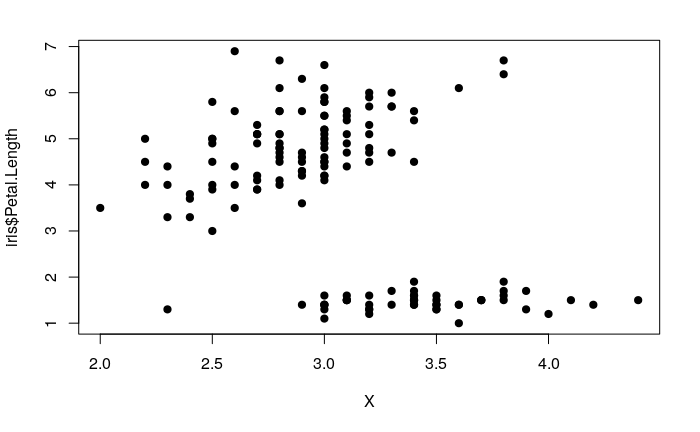

```r
plot(X, iris$Petal.Length, pch=19)
```

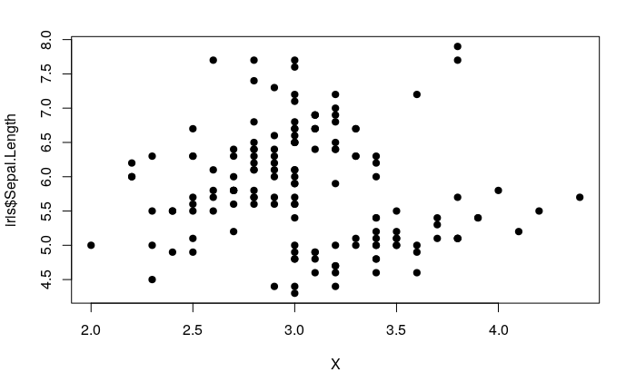

```r
plot(X, iris$Sepal.Length, pch=19)
```

#### 2. Put a threshold (limit) to isolate the data points of the first cluster corresponding to lower values of petal length and petal width. Examine if these belong to same species, by checking the data variable ‘Species’.

```r
indices <- iris$Petal.Width < 0.8 & iris$Petal.Length < 2.5
species <- unique(iris$Species[indices])
```

They all seem to belong to the same species - **setosa**.

### 7)

#### i) Establish the 95% confidence interval for the true mean of X based on all the X data.

```r
margin_error <- qnorm(.975)*(X.sd/sqrt(length(X)))
ll_i <- X.mean - margin_error
ul_i <- X.mean + margin_error
```

The **lower limit is *2.9875815*** and the **upper limit is *3.1270852***

#### ii) Take a subset, S, of X that includes only the X values of the species that was identified in 3.6. Establish the 95% confidence interval for the true mean X based on this sample subset.

```r
S <- X[indices]
S.mean <- mean(S)
S.sd <- sd(S)
margin_error <- qnorm(.975)*(S.sd/sqrt(length(S)))
ll_ii <- S.mean - margin_error
ul_ii <- S.mean + margin_error
```

The **lower limit is *3.3229306*** and the **upper limit is *3.5330694***

#### iii) Are both samples large enough for such statistical study? What type of statistical study is this, what does it consist in, and how does it compare to the approach used in 3.5?

Both samples can be considered large enough for this statistical study, in general we can consider a sample size $n$ to be large enough when $n>30$.

The confidence interval is a type of estimate computed from the statistics of the observed data. In this particular case we are using the mean and standard deviation of our sample. We have a 95% confidence level that the estimated interval will contain the true value of the population parameter.

This is different from the study conducted in 3.5 because we were considering X to be a normally distributed population. We could easily calculate the true mean of the population.